# Stock Price Comparison

Debjit Ray

15/03/2020

10. Find the daily stock price of Wal-.- Mart for the last three months. (A good source for the data is http://moneycentral.msn.com or Yahoo Finance or Google Finance (there are many more such sources). You can ask for the three-.-month chart and export the data to a spreadsheet.)
1. Calculate the mean and the standard deviation of the stock prices.
2. Get the corresponding data for Kmart and calculate the mean and the standard deviation.
3. The coefficient of variation (CV)is defined as the ratio of the standard deviation over the mean. Calculate the CV of Wal-.-Mart and Kmart stock prices.
4. If the CV of the daily stock prices is taken as an indicator of risk of the stock, how do Wal-.-Mart and Kmart stocks compare in terms of risk? (There are better measures of risk, but we will use CV in this exercise.)
5. Get the corresponding data of the Dow Jones Industrial Average (DJIA) and compute its CV. How do Wal-.- Mart and Kmart stocks compare with the DJIA in terms of risk?
6. Suppose you bought 100 shares of Wal-.-Mart stock three months ago and held it. What are the mean and the standard deviation of the daily market price of your holding for the three months?

### Solution

```r
#-------------------------------------------------------------------------------------------------------
# (a) Mean and Standard Deviation for Walmart
#-------------------------------------------------------------------------------------------------------
# Download the file into the data folder
fileUrl <-"https://query1.finance.yahoo.com/v7/finance/download/WMT?period1=1552848067&period2=1584470467&interval=1d&events=history"
if (!file.exists("./data/WalmartStockPrice.csv")){
  download.file(fileUrl, destfile = "./data/WalmartStockPrice.csv")
  print (paste("File downloaded on: ", date()))
}

# Read the downloaded data into a dataframe
WalmartPrice <- read.csv("./data/WalmartStockPrice.csv",header = TRUE, stringsAsFactors = FALSE)

#Calculate the average prices
avgWMTOpen <- mean(WalmartPrice$Open)
avgWMTHigh <- mean(WalmartPrice$High)
avgWMTLow <- mean(WalmartPrice$Low)
avgWMTClose <- mean(WalmartPrice$Close)
avgWMTAdjClose <- mean(WalmartPrice$Adj.Close)
#Calculate the standard deviations of the prices
sdWMTOpen <- round(sd(WalmartPrice$Open), digits = 5)
sdWMTHigh <- round(sd(WalmartPrice$High), digits = 5)
sdWMTLow <- round(sd(WalmartPrice$Low), digits = 5)
sdWMTClose <- round(sd(WalmartPrice$Close), digits = 5)
sdWMTAdjClose <- round(sd(WalmartPrice$Adj.Close), digits = 5)
dateRangeStartWMT <- min(WalmartPrice$Date)
dateRangeEndWMT <- max(WalmartPrice$Date)

# Store the results into a dataframe
resultsDF <- data.frame("Walmart","WMT",dateRangeStartWMT, dateRangeEndWMT,
                        "Open_Price", avgWMTOpen, sdWMTOpen,
                        stringsAsFactors = FALSE)
resultsDF[nrow(resultsDF) + 1,] <- list("Walmart","WMT",dateRangeStartWMT, dateRangeEndWMT,
                                        "High_Price", avgWMTHigh,  sdWMTHigh)
resultsDF[nrow(resultsDF) + 1,] <- list("Walmart","WMT",dateRangeStartWMT, dateRangeEndWMT,
                                        "Low_Price", avgWMTLow,  sdWMTLow)
resultsDF[nrow(resultsDF) + 1,] <- list("Walmart","WMT",dateRangeStartWMT, dateRangeEndWMT,
                                        "Close_Price", avgWMTClose,  sdWMTClose)
resultsDF[nrow(resultsDF) + 1,] <- list("Walmart","WMT",dateRangeStartWMT, dateRangeEndWMT,
                                        "Adjusted_Close_Price", avgWMTAdjClose,  sdWMTAdjClose)

# All column names to the dataframe
colnames(resultsDF) <- list("Stock_Name","Stock_Symbol","Start_Date","End_Date","Price_Type",
                            "Mean_Price", "SD_Price")
# Display the data
resultsDF[which (resultsDF$Stock_Symbol == "WMT"),]
```

```
##   Stock_Name Stock_Symbol Start_Date   End_Date           Price_Type Mean_Price
## 1    Walmart          WMT 2019-03-18 2020-03-17           Open_Price   112.0796
## 2    Walmart          WMT 2019-03-18 2020-03-17           High_Price   112.9994
## 3    Walmart          WMT 2019-03-18 2020-03-17            Low_Price   111.2519
## 4    Walmart          WMT 2019-03-18 2020-03-17          Close_Price   112.1752
## 5    Walmart          WMT 2019-03-18 2020-03-17 Adjusted_Close_Price   111.5388
##   SD_Price
## 1  7.20128
## 2  7.15700
## 3  7.14320
## 4  7.10149
## 5  7.48968
```

```r
#-------------------------------------------------------------------------------------------------------
# (b) Mean and Standard Deviation for Sears
#-------------------------------------------------------------------------------------------------------
# Download the file into the data folder
fileUrl <-"https://query1.finance.yahoo.com/v7/finance/download/SHLDQ?period1=1579305600&period2=1584489600&interval=1d&events=history"
if (!file.exists("./data/SearsStockPrice.csv")){
  download.file(fileUrl, destfile = "./data/SearsStockPrice.csv")
  print (paste("Sears Stock Price File downloaded on: ", date()))
}

# Read the downloaded data into a dataframe
searsPrice <- read.csv("./data/SearsStockPrice.csv",header = TRUE, stringsAsFactors = FALSE)

#Calculate the average prices
avgSHLDQOpen <- mean(searsPrice$Open)
avgSHLDQHigh <- mean(searsPrice$High)
avgSHLDQLow <- mean(searsPrice$Low)
avgSHLDQClose <- mean(searsPrice$Close)
avgSHLDQAdjClose <- mean(searsPrice$Adj.Close)
#Calculate the standard deviations of the prices
sdSHLDQOpen <- round(sd(searsPrice$Open), digits = 5)
sdSHLDQHigh <- round(sd(searsPrice$High), digits = 5)
sdSHLDQLow <- round(sd(searsPrice$Low), digits = 5)
sdSHLDQClose <- round(sd(searsPrice$Close), digits = 5)
sdSHLDQAdjClose <- round(sd(searsPrice$Adj.Close), digits = 5)
dateRangeStartSHLDQ <- min(searsPrice$Date)
dateRangeEndSHLDQ <- max(searsPrice$Date)

# Add the result for Sears to the dataframe

resultsDF[nrow(resultsDF) + 1,] <- list("Sears","SHLDQ",dateRangeStartSHLDQ, dateRangeEndSHLDQ,
                                        "Open_Price", avgSHLDQOpen,  sdSHLDQOpen)
resultsDF[nrow(resultsDF) + 1,] <- list("Sears","SHLDQ",dateRangeStartSHLDQ, dateRangeEndSHLDQ,
                                        "High_Price", avgSHLDQHigh,  sdSHLDQHigh)
resultsDF[nrow(resultsDF) + 1,] <- list("Sears","SHLDQ",dateRangeStartSHLDQ, dateRangeEndSHLDQ,
                                        "Low_Price", avgSHLDQLow,  sdSHLDQLow)
resultsDF[nrow(resultsDF) + 1,] <- list("Sears","SHLDQ",dateRangeStartSHLDQ, dateRangeEndSHLDQ,
                                        "Close_Price", avgSHLDQClose,  sdSHLDQClose)
resultsDF[nrow(resultsDF) + 1,] <- list("Sears","SHLDQ",dateRangeStartSHLDQ, dateRangeEndSHLDQ,
                                        "Adjusted_Close_Price", avgSHLDQAdjClose, sdSHLDQAdjClose)

#Display the data
resultsDF[which (resultsDF$Stock_Symbol == "SHLDQ"),]
```

```
##    Stock_Name Stock_Symbol Start_Date   End_Date           Price_Type
## 6       Sears        SHLDQ 2020-01-21 2020-03-17           Open_Price
## 7       Sears        SHLDQ 2020-01-21 2020-03-17           High_Price
## 8       Sears        SHLDQ 2020-01-21 2020-03-17            Low_Price
## 9       Sears        SHLDQ 2020-01-21 2020-03-17          Close_Price
## 10      Sears        SHLDQ 2020-01-21 2020-03-17 Adjusted_Close_Price
##    Mean_Price SD_Price
## 6    0.250685  0.05359
## 7    0.267500  0.05438
## 8    0.238935  0.05054
## 9    0.249875  0.05466
## 10   0.249875  0.05466
```

```r
#-------------------------------------------------------------------------------------------------------
# (c) Calculate the Coefficient of Variation for Walmart and Sears
#-------------------------------------------------------------------------------------------------------

# Calculate the coefficient of variation and append the details to the data frame
resultsDF <- cbind(resultsDF,list(
          "CV" = round(resultsDF$SD_Price/resultsDF$Mean_Price,5)))
# Display the data
resultsDF
```

```
##    Stock_Name Stock_Symbol Start_Date   End_Date           Price_Type
## 1     Walmart          WMT 2019-03-18 2020-03-17           Open_Price
## 2     Walmart          WMT 2019-03-18 2020-03-17           High_Price
## 3     Walmart          WMT 2019-03-18 2020-03-17            Low_Price
## 4     Walmart          WMT 2019-03-18 2020-03-17          Close_Price
## 5     Walmart          WMT 2019-03-18 2020-03-17 Adjusted_Close_Price
## 6       Sears        SHLDQ 2020-01-21 2020-03-17           Open_Price
## 7       Sears        SHLDQ 2020-01-21 2020-03-17           High_Price
## 8       Sears        SHLDQ 2020-01-21 2020-03-17            Low_Price
## 9       Sears        SHLDQ 2020-01-21 2020-03-17          Close_Price
## 10      Sears        SHLDQ 2020-01-21 2020-03-17 Adjusted_Close_Price
##    Mean_Price SD_Price      CV
## 1  112.079605  7.20128 0.06425
## 2  112.999407  7.15700 0.06334
## 3  111.251899  7.14320 0.06421
## 4  112.175178  7.10149 0.06331
## 5  111.538819  7.48968 0.06715
## 6    0.250685  0.05359 0.21377
## 7    0.267500  0.05438 0.20329
## 8    0.238935  0.05054 0.21152
## 9    0.249875  0.05466 0.21875
## 10   0.249875  0.05466 0.21875
```

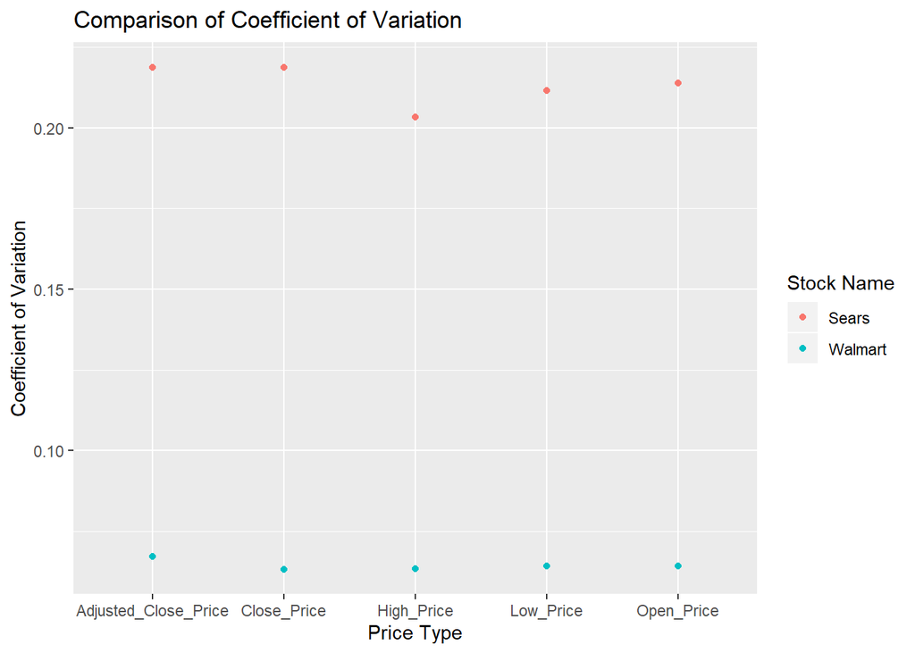

```r
#-------------------------------------------------------------------------------------------------------
# (d) Plot a graph to relatively compare the Coefficient of Variation of the prices
#-------------------------------------------------------------------------------------------------------

library(ggplot2)
ggplot(resultsDF, aes(resultsDF$Price_Type, resultsDF$CV )) + geom_point(aes(color = resultsDF$Stock_Name)) + ggtitle("Comparison of Coefficient of Variation") + labs(x = "Price Type", y = "Coefficient of Variation") + labs(color='Stock Name')
```

As evident from the plotted graph, the Coefficient of Variation for Sears is much higher than Walmart. This means the price swing (standard deviation) as compared to the mean price for Sears can vary more on both positive and negative side, thus, yielding more positive/ negative returns. In other words, the returns compared to the risk of investment in Sears is more than that in Walmart.

**Hence, Sears is the more risky option.**

```r
#-------------------------------------------------------------------------------------------------------
# (e) Get the corresponding data for Dow Jones Industrial Estate and compare against Sears and Walmart
#-------------------------------------------------------------------------------------------------------
# Download the file into the data folder
fileUrl <-"https://query1.finance.yahoo.com/v7/finance/download/%5EDJI?period1=1579305600&period2=1584489600&interval=1d&events=history"
if (!file.exists("./data/DowJones.csv")){
  download.file(fileUrl, destfile = "./data/DowJones.csv")
  print (paste("Dow Jones Industrial Average File downloaded on: ", date()))
}

# Read the downloaded data into a dataframe
DowJonesPrice <- read.csv("./data/DowJones.csv",header = TRUE, stringsAsFactors = FALSE)

#Calculate the average prices
avgDJIAOpen <- mean(DowJonesPrice$Open)
avgDJIAHigh <- mean(DowJonesPrice$High)
avgDJIALow <- mean(DowJonesPrice$Low)
avgDJIAClose <- mean(DowJonesPrice$Close)
avgDJIAAdjClose <- mean(DowJonesPrice$Adj.Close)
#Calculate the standard deviations of the prices
sdDJIAOpen <- round(sd(DowJonesPrice$Open), digits = 5)
sdDJIAHigh <- round(sd(DowJonesPrice$High), digits = 5)
sdDJIALow <- round(sd(DowJonesPrice$Low), digits = 5)
sdDJIAClose <- round(sd(DowJonesPrice$Close), digits = 5)
sdDJIAAdjClose <- round(sd(DowJonesPrice$Adj.Close), digits = 5)
dateRangeStartDJIA <- min(DowJonesPrice$Date)
dateRangeEndDJIA <- max(DowJonesPrice$Date)

# Add the result for DowJones to the dataframe

resultsDF[nrow(resultsDF) + 1,] <- list("DowJones","DJIA",dateRangeStartDJIA, dateRangeEndDJIA,
                                        "Open_Price", avgDJIAOpen,  sdDJIAOpen,
                                        round(sdDJIAOpen/avgDJIAOpen,5))
resultsDF[nrow(resultsDF) + 1,] <- list("DowJones","DJIA",dateRangeStartDJIA, dateRangeEndDJIA,
                                        "High_Price", avgDJIAHigh,  sdDJIAHigh,
                                        round(sdDJIAHigh/avgDJIAHigh,5))
resultsDF[nrow(resultsDF) + 1,] <- list("DowJones","DJIA",dateRangeStartDJIA, dateRangeEndDJIA,
                                        "LowPrice", avgDJIALow,  sdDJIALow,
                                        round(sdDJIALow/avgDJIALow,5))
resultsDF[nrow(resultsDF) + 1,] <- list("DowJones","DJIA",dateRangeStartDJIA, dateRangeEndDJIA,
                                        "Close_Price", avgDJIAClose,  sdDJIAClose,
                                        round(sdDJIAClose/avgDJIAClose,5))
resultsDF[nrow(resultsDF) + 1,] <- list("DowJones","DJIA",dateRangeStartDJIA, dateRangeEndDJIA,
                                        "Adjusted_Close_Price", avgDJIAAdjClose,  sdDJIAAdjClose,
                                        round(sdDJIAAdjClose/avgDJIAAdjClose,5))
# Display the data
resultsDF[which (resultsDF$Stock_Symbol == "DJIA"),]
```

```
##    Stock_Name Stock_Symbol Start_Date   End_Date           Price_Type
## 11   DowJones         DJIA 2020-01-21 2020-03-17           Open_Price
## 12   DowJones         DJIA 2020-01-21 2020-03-17           High_Price
## 13   DowJones         DJIA 2020-01-21 2020-03-17             LowPrice
## 14   DowJones         DJIA 2020-01-21 2020-03-17          Close_Price
## 15   DowJones         DJIA 2020-01-21 2020-03-17 Adjusted_Close_Price
##    Mean_Price SD_Price      CV
## 11   27365.22 2539.283 0.09279
## 12   27626.09 2308.104 0.08355
## 13   26982.30 2796.679 0.10365
## 14   27286.19 2575.004 0.09437
## 15   27286.19 2575.004 0.09437
```

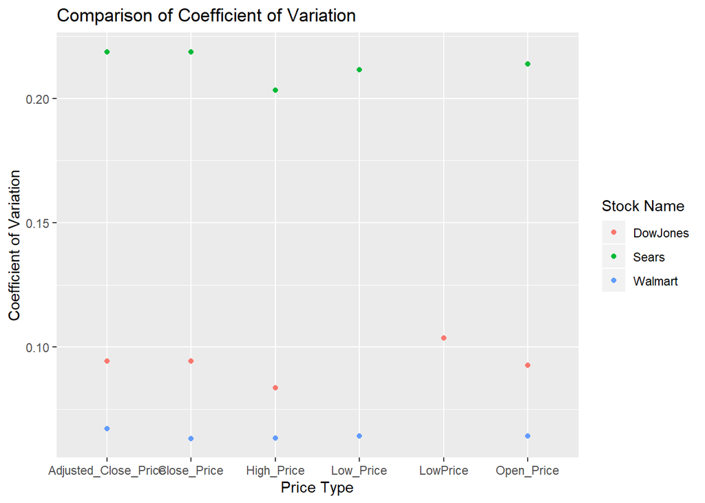

```r
# Plot the graph
library(ggplot2)
ggplot(resultsDF, aes(resultsDF$Price_Type, resultsDF$CV )) + geom_point(aes(color = resultsDF$Stock_Name)) + ggtitle("Comparison of Coefficient of Variation") + labs(x = "Price Type", y = "Coefficient of Variation") + labs(color='Stock Name')
```

On comparison with Dow Jones Industrial Average, we find the Coefficient of Variation for Sears is much higher and that of Walmart is lower. This signifies Sears had a higher risk-return ratio than the industrial average. Walmart had a further lower risk-return ratio than Dow Jones.

**Thus, Walmart had the least risk-return ratio, making it the safest bet as it outperformed Dow Jones Coefficient of Variation. Sears had high risk-return ratio, even more than Dow Jones; thus, making it the most risky bet.**

```r
#-------------------------------------------------------------------------------------------------------
# (e) Calculate Mean and the Standard deviation of the daily market price of holding 100 stocks of
#     Walmart for 3 months
#-------------------------------------------------------------------------------------------------------
#Create new dataframe for storing the portfolio data
dfWMTHolding <- WalmartPrice[,1:6] # Removed the volume column
dfWMTHolding$Quantity <- 100
dfWMTHolding$PrtflOpen <- dfWMTHolding$Quantity * dfWMTHolding$Open
dfWMTHolding$PrtflHigh <- dfWMTHolding$Quantity * dfWMTHolding$High
dfWMTHolding$PrtflLow <- dfWMTHolding$Quantity * dfWMTHolding$Low
dfWMTHolding$PrtflClose <- dfWMTHolding$Quantity * dfWMTHolding$Close
dfWMTHolding$PrtflAdjClose <- dfWMTHolding$Quantity * dfWMTHolding$Adj.Close

#Calculate the average prices
avgHldngOpen <- mean(dfWMTHolding$PrtflOpen)
avgHldngHigh <- mean(dfWMTHolding$PrtflHigh)
avgHldngLow <- mean(dfWMTHolding$PrtflLow)
avgHldngClose <- mean(dfWMTHolding$PrtflClose)
avgHldngAdjClose <- mean(dfWMTHolding$PrtflAdjClose)
#Calculate the standard deviations of the prices
sdHldngOpen <- round(sd(dfWMTHolding$PrtflOpen), digits = 5)
sdHldngHigh <- round(sd(dfWMTHolding$PrtflHigh), digits = 5)
sdHldngLow <- round(sd(dfWMTHolding$PrtflLow), digits = 5)
sdHldngClose <- round(sd(dfWMTHolding$PrtflClose), digits = 5)
sdHldngAdjClose <- round(sd(dfWMTHolding$PrtflAdjClose), digits = 5)
dateRangeStartHldng <- min(dfWMTHolding$Date)
dateRangeEndHldng <- max(dfWMTHolding$Date)

# Store the results into a dataframe
prtflAnalysisDF <- data.frame("Walmart","WMT",dateRangeStartHldng, dateRangeEndHldng,
                        "Open_Market_Value", avgHldngOpen, sdHldngOpen,
                        stringsAsFactors = FALSE)

# All column names to the dataframe
colnames(prtflAnalysisDF) <- list("Stock_Name","Stock_Symbol","Start_Date","End_Date","Market_Value_Type",
                            "Mean_MV", "SD_MV")

prtflAnalysisDF[nrow(prtflAnalysisDF) + 1,] <- list("Walmart","WMT",
                                               dateRangeStartHldng, dateRangeEndHldng,
                                              "High_Market_Value", avgHldngHigh,  sdHldngHigh)
prtflAnalysisDF[nrow(prtflAnalysisDF) + 1,] <- list("Walmart","WMT",
                                               dateRangeStartHldng, dateRangeEndHldng,
                                               "Low_Market_Value", avgHldngLow,  sdHldngLow)
prtflAnalysisDF[nrow(prtflAnalysisDF) + 1,] <- list("Walmart","WMT",
                                               dateRangeStartHldng, dateRangeEndHldng,
                                               "Close_Market_Value", avgHldngClose,  sdHldngClose)
prtflAnalysisDF[nrow(prtflAnalysisDF) + 1,] <- list("Walmart","WMT",
                                              dateRangeStartHldng, dateRangeEndHldng,
                                              "Adjusted_Close_Market_Value", avgHldngAdjClose,
                                               sdHldngAdjClose)
prtflAnalysisDF
```

```
##   Stock_Name Stock_Symbol Start_Date   End_Date           Market_Value_Type
## 1    Walmart          WMT 2019-03-18 2020-03-17           Open_Market_Value
## 2    Walmart          WMT 2019-03-18 2020-03-17           High_Market_Value
## 3    Walmart          WMT 2019-03-18 2020-03-17            Low_Market_Value
## 4    Walmart          WMT 2019-03-18 2020-03-17          Close_Market_Value
## 5    Walmart          WMT 2019-03-18 2020-03-17 Adjusted_Close_Market_Value
##    Mean_MV    SD_MV
## 1 11207.96 720.1276
## 2 11299.94 715.7002
## 3 11125.19 714.3196
## 4 11217.52 710.1495
## 5 11153.88 748.9682
```